# Notebooks

[figure not shown]

- Previously known as "IPython notebooks"

# What's good about notebooks?

- They can run any Python (or increasingly, other languages) that you want
- They are "rich" documents (I.e., they include LaTeX, plots, sounds, animations, etc.)
- They are easily shared (just put them on github or anywhere else on the internet)
- They are easy to maintain (they are just JSON files, no fancy database or anything required)

Or in short:

## They make science easier and more reproducible

Compare this: https://gist.github.com/eteq/7b54c9cc1cb23cfe9a1ad1afd70bea9f

To this: https://github.com/eteq/piscdwarfs_hst/blob/master/Calibed%20Photometry.ipynb

# How do you use them?

(Start `jupyter notebook` from wherever all your stuff is for a project)

Create a notebook, and start typing Python code:

```python
from astropy import coordinates

coordinates.SkyCoord.from_name('M31')
```

Hit shift-enter (or control-enter)

```python
from astropy import coordinates

coordinates.SkyCoord.from_name('M82')
```

```
<SkyCoord (ICRS): (ra, dec) in deg
    (148.9684583, 69.6797028)>
```

## Some Tips

Pay attention to the color of the box around the cell: green means "edit" mode (typing will edit the code), blue means "Command Mode" (typing will move/insert/execute cells).

Try the "multi select" mode (hold down cmd or ctrl while clicking on different parts of text in a cell) - every keystroke goes to *all* of the cursors.

Use `?` to get help on a function - it appears in a pop-up bar at the bottom of the notebook

Check out the `%magic` list: lots of useful productivity tools (from IPython)

To learn more, open a notebook and go to "Help"->"User interface tour" or "Help"->"Keyboard Shortcuts"

# Some neat things you can do with notebooks

## Make plots

```python
%matplotlib inline

from matplotlib import pyplot as plt
import numpy as np
```

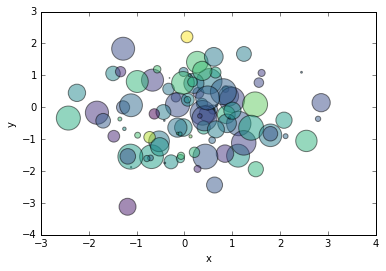

```python
plt.scatter(*np.random.randn(2, 100),
            s=np.pi * (15 * np.random.rand(100))**2 ,
            c=np.random.randn(100), alpha=0.5,
            cmap='viridis')
plt.xlabel('x')
plt.ylabel('y')
```

## Render LaTeX

```
$M(r) = - \frac{r \sigma^2}{G}
          \left[ \frac{d \ln \nu}{d \ln r} +
                 \frac{d \ln \sigma^2}{d \ln r} +
                  2 \beta(r)
          \right]$
```

$M(r) = - \frac{r \sigma^2}{G} \left[ \frac{d \ln \nu}{d \ln r} + \frac{d \ln \sigma^2}{d \ln r} + 2 \beta(r) \right]$

## Embed images

```python
from IPython import display

urltempl = ("http://skyservice.pha.jhu.edu/dr12/ImgCutout/getjpeg.aspx?"
            "ra={coo.ra.deg}&dec={coo.dec.deg}&width={width}&height={height}&scale={scale}")
m101 = coordinates.SkyCoord.from_name('M101')
display.Image(url=urltempl.format(coo=m101, width=1024, height=768, scale=1.25))
```

[figure not shown]

## Test/time your code

```python
%timeit np.sqrt(12)
```

```
The slowest run took 14.82 times longer than the fastest. This could mean that an intermediate result is being cached.
1000000 loops, best of 3: 1.07 µs per loop
```

```python
%timeit 12**0.5
```

```
10000000 loops, best of 3: 22.4 ns per loop
```

## Show animations

```python
from matplotlib import animation
# Details of this one's implementation are in a hidden slide
animation.FuncAnimation(lorenz_fig, func=lorenz_animate,
                        init_func=lorenz_init, blit=True,
                        frames=500, interval=30)
```

[video not shown]

## Make presentations

The one you're seeing here!